# R for Data Science #1

## 4.3 Character Strings

- `paste()` , `paste0()` : sticks together two character vectors, and if its necessary convert them into a `character` vector first. By default it will insert a space between them.
  - `sep=` to choose the separation, e.g. `sep="."` or `sep=""` .
  - `collapse=` combines all the strings of the vector into one long string. It will use the separator specified by the value of this argument. e.g. `collapse=""` or `="\t"` .

```r
paste("a", "b", "c")
```

```
[1] "a b c"
```

```r
paste0( 1 == 2, 1 + 2)
```

```
[1] "FALSE3"
```

```r
paste0("Arg", sep=".", LETTERS[3:7])
```

```
[1] "Arg.C" "Arg.D" "Arg.E" "Arg.F" "Arg.G"
```

```r
paste(letters[1:5], LETTERS[5:1], collapse = ", ")
```

```
[1] "a E, b D, c C, d B, e A"
```

### 4.3.1 Column Names

When a data frame is constructed from data without header names, R construct names such as V1 and V2. Usually we will want to replace these names to others more meaningful.

For example, we want column names for 36 months of balance data from 2021 to 2023, also 36 months of payment data for the same years.

- `outer()` : given two vectors, performs another function on each pair of elements producing a matrix.
- `expand.grid()` : given vectors of values produces a data frame containing all combinations of all the values.

```r
head (
    outer (month.abb, 2021:2023, paste, sep = "." ), 5
)
```

```
     [,1]       [,2]       [,3]
[1,] "Jan.2021" "Jan.2022" "Jan.2023"
[2,] "Feb.2021" "Feb.2022" "Feb.2023"
[3,] "Mar.2021" "Mar.2022" "Mar.2023"
[4,] "Apr.2021" "Apr.2022" "Apr.2023"
[5,] "May.2021" "May.2022" "May.2023"
```

```r
# Creating the month sequence for each year
monseq <- outer (month.abb, 2021:2023, paste, sep = "." )
# Creating the column names
newnam <- c("ID",
            paste0 ("Bal.", monseq),
            paste0 ("Pay.", monseq) )

sample(newnam, 5)
```

```
[1] "Pay.Oct.2022" "Pay.Aug.2023" "Pay.Jul.2023" "Bal.Feb.2022" "Pay.Sep.2023"
```

```r
# Alternative maybe more eficient but more tedious
p1 <- rep (c("Bal", "Pay"), 12 * 3)
# Each month 2 times for Bal and Pay, and then 3 times for the years
p2 <- rep ( rep(month.abb, each = 2), 3 )
# Each year two times, for Bal and Pay
p3 <- rep (2021:2023, each = 24)

newnam <- c("ID", paste(p1, p2, p3, sep=".") )
sample(newnam, 5)
```

```
[1] "Pay.Dec.2021" "Pay.Apr.2023" "Pay.Jun.2021" "Pay.Dec.2022" "Pay.Sep.2023"
```

```r
names.df <- expand.grid (c("Bal", "Pay"),
                         month.abb,
                         c(2021:2023) )

newnam <- paste ( names.df[["Var1"]],
                  names.df[["Var2"]],
                  names.df[["Var3"]],
                  sep = "." )

sample(newnam, 5)
```

```
[1] "Pay.Oct.2021" "Bal.Jun.2021" "Pay.Jul.2022" "Pay.May.2021" "Pay.Jun.2021"
```

### 4.3.2 Tabulating Dates

To summarize vectors of dates:

```r
set.seed(168)
rnd.dts <- as.Date (sample (0:730, size = 600), origin = "2021-01-01")

table (quarters (rnd.dts) )
```

```
 Q1  Q2  Q3  Q4
153 139 154 154
```

```r
table ( paste0 (format (rnd.dts, "%Y"), ".", quarters(rnd.dts) ) )
```

```
2021.Q1 2021.Q2 2021.Q3 2021.Q4 2022.Q1 2022.Q2 2022.Q3 2022.Q4 2023.Q1
     79      68      75      78      73      71      79      76       1
```

If we want to use the month instead of the quarter, we can extract the moth name with `month()` function and use paste, or it is possible to use `format()` directly with the year and the month name.

```r
ym.order <- paste0 (2021:2023, ".", month.name )

ym.tbl <- table (format(rnd.dts, "%Y.%B") )

ym.tbl[ym.order][1:5]
```

```
 2021.January 2022.February          <NA>    2021.April      2022.May
           26            20                          20            24
```

### 4.3.3 Unique Keys

Often we need to construct a column with an unique identifier for each row. These previous methods are useful for that task. Maybe the year and month are not enough and we have to add a customer ID or something else to achieve this column with unique keys.

### 4.3.4 Files and Path names

To create a vector with every file in the working directory and each one with it absolute path we can use `paste(getwd(), list.files(), sep="/")` . If we use `list.files(full.names=TRUE)` will return only the relative path.

## 4.4 Regular Expressions

We use regular expressions to find strings that match a pattern. This patterns are case-sensitive but can be ignored. R can use POSIX regular expression and Perl-style re.

For regular expresson in R there are three primary tools which are `grep()`, `regexpr()` and `sub()`, all tree with its variants.

- `grep()` : given a pattern and a vector of strings, returns a numeric vector with the indices of the string that match the pattern.
  - `value=` if `TRUE` returns the matching string themselves.
  - `ignore.case=` if `TRUE` will ignore whether letters are in upper or lower-case.
  - `invert=` if `TRUE` reverses the search, returning the elements that not match. It’s not available with `grepl()`
  - `fixed=` if `TRUE` suspends the rules about patterns and simply searches for an exact text string.
  - `perl=` if `TRUE` indicate to grep() to use Perl-type regular expressions.
  - `useBytes=` if `TRUE` the matching should be done byte by byte.
- `grepl()` : returns a logical vector indicating the elements that match.

Special Characters in POSIX regular expressions:

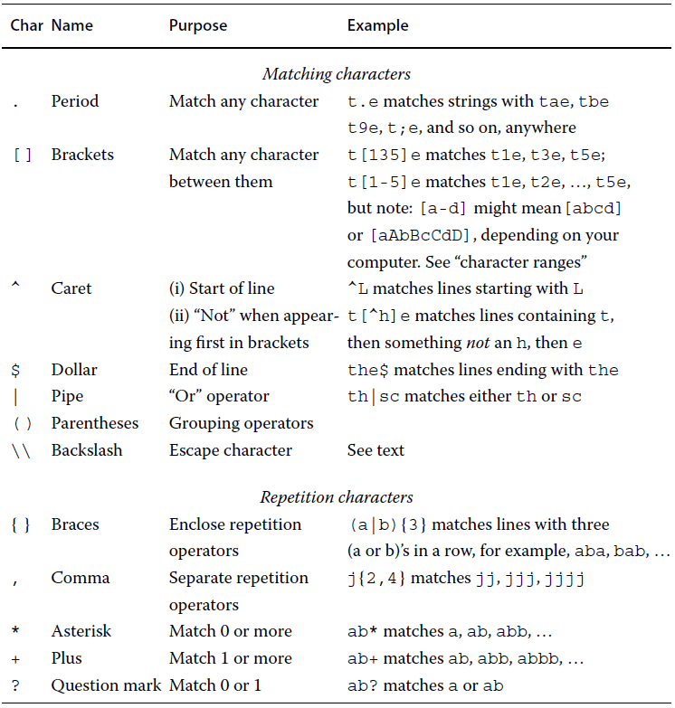

It is common to see `.+` in regular expressions, that means *a sequence of one or more characters*. Also we can see `.*` for *zero or more characters*.

Is is a mistake to add spaces to your pattern thinking ‘it will be more readable’, because the regular expression will then take the spaces literally and require that they appear.

Looking in a character vector with dates:

```r
dt <- c(
    "Balance due 16 Jun or earlier in 2017",
    "26 Aug or any day in 3021",
    "'76 Trombones' marched in a 1962 film",
    "4 Apr 2018", "9Aug2006",
    "99 Voters May Register in 20188"
)
```

- `.*` if we have leading text
- `[0-3]?[0-9]` matches a one digit number, the first digit is optional indicated by ‘?’
- `.*` again for additional text
- `(", or.mon, ")` will be the variable with the month names separated by pipes `"|"`. The parenthesis make this a single pattern. The abbreviations will match a full name.
- `.*` more additional text
- `[1-2][0-9[{3}` four digits that have to start with 1 or 2

```r
or.mon <- paste (month.abb, collapse = "|")
or.mon
```

```
[1] "Jan|Feb|Mar|Apr|May|Jun|Jul|Aug|Sep|Oct|Nov|Dec"
```

```r
re <- paste0 ( ".*[0-3]?[0-9].*(", or.mon, ").*[1-2][0-9]{3}")
grep (re, dt, value = TRUE )
```

```
[1] "Balance due 16 Jun or earlier in 2017" "4 Apr 2018"
[3] "9Aug2006"                              "99 Voters May Register in 20188"
```

The line with ‘20188’ match because the four digits with `[1-2][0-9]{3}` match. Also the ‘99’ matches because `[0-3]` is optional and the first 9 matches in the `[0-9]` pattern and the second match with `.*` .

#### 4.4.0.1 Escape Sequences